# FRED inflation

## Necessary packages

```r
library(MASS) # for the stepAIC() function
library(quantmod) # Extracting data
library(tsibble)
library(tidyverse)
library(ggplot2)
library(scales)
library(aTSA)
library(dynlm)
library(car)
library(sandwich)
library(modelsummary)
library(leaps) # for the leaps() function
```

## Extracting the data from FRED and indexing:

This code chunk below uses the quantmod package to get FRED data via its API.

```r
cpi=getSymbols('CPIAUCSL',src='FRED',auto.assign=F)['1992-01-01/']
cpi=cpi/cpi[[1]]*100
ppi=getSymbols('PITGCG01USM661N',src='FRED',auto.assign=F)['1992-01-01/']
ppi=ppi/ppi[[1]]*100
energy=getSymbols('PNRGINDEXM',src='FRED',auto.assign=F)['1992-01-01/']
energy=energy/energy[[1]]*100
food=getSymbols('PFOODINDEXM',src='FRED',auto.assign=F)['1992-01-01/']
food=food/food[[1]]*100
used_cars=getSymbols('CUSR0000SETA02',src='FRED',auto.assign=F)['1992-01-01/']
used_cars=used_cars/used_cars[[1]]*100
housing=getSymbols('CPIHOSNS',src='FRED',auto.assign=F)['1992-01-01/']
Unemployment=getSymbols('UNRATE',src='FRED',auto.assign=F)['1992-01-01/']/100
Electricity_avg=getSymbols('APU000072610',src='FRED',auto.assign=F)['1992-01-01/']
Electricity_avg=Electricity_avg/Electricity_avg[[1]]*100
```

## EDA:

For all indices

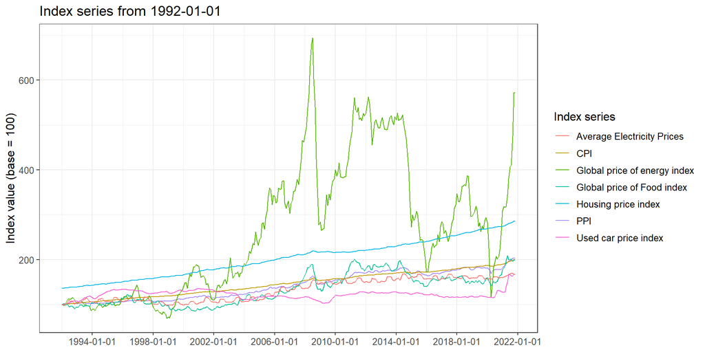

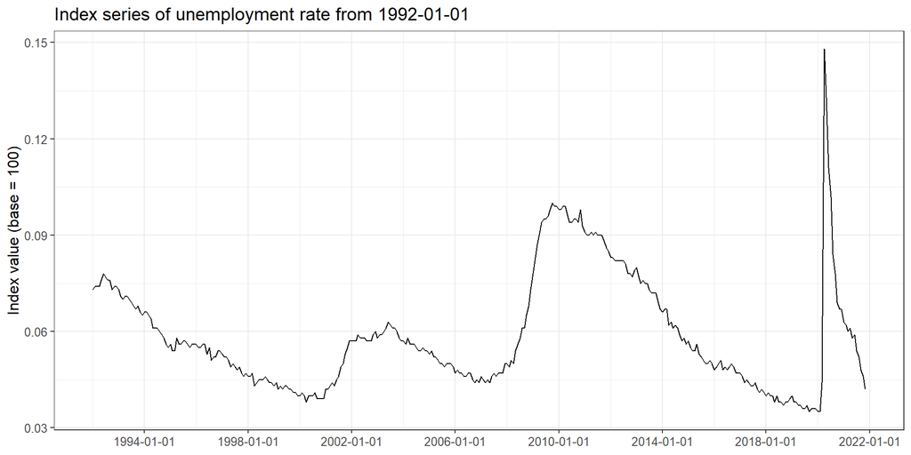

Big Spike for Unemployment during covid that might have a significant impact on model. This informs our rationale to test COVID as a factor of inflation.

All of our series are non-stationary in their current form. As such, we choose to: 1. Take the log of all indices (so this excludes unemployment rate) 2. Take the first difference of the logged series, and the first difference of unemployment rate.

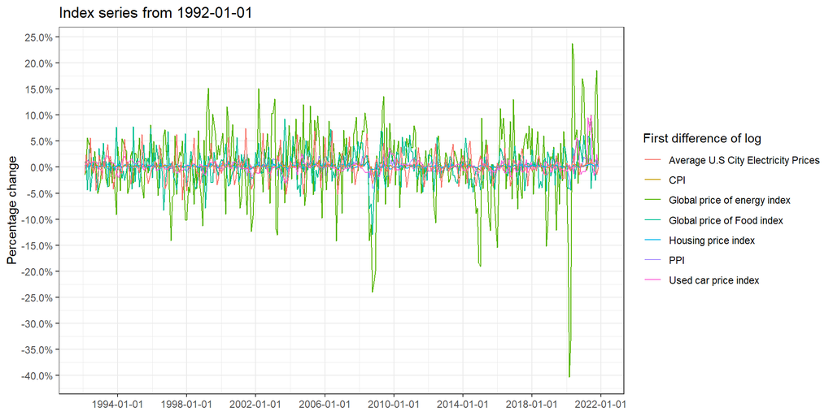

```r
ggplot(data=NULL,aes(x=final_ts_df$Date[-1]))+
  geom_line(aes(y=diff(log(final_ts_df$PPI)),color="PPI"))+
  geom_line(aes(y=diff(log(final_ts_df$CPI)),color="CPI"))+
  geom_line(aes(y=diff(log(final_ts_df$Energy)),color="Global price of energy index"))+
  geom_line(aes(y=diff(log(final_ts_df$Food)),color="Global price of Food index"))+
  geom_line(aes(y=diff(log(final_ts_df$Used_cars)),color="Used car price index"))+
  geom_line(aes(y=diff(log(final_ts_df$Housing_prices)),color="Housing price index"))+
  geom_line(aes(y=diff(log(final_ts_df$AvgElectricityPrices)),color="Average U.S City Electricity Prices"))+
  theme_bw()+ylab("Percentage change")+xlab(NULL)+
  scale_x_date(date_breaks="4 year")+
  scale_y_continuous(labels=scales::percent,breaks=scales::pretty_breaks(n=20))+
  labs(colour="First difference of log")+ggtitle("Index series from 1992-01-01")
```

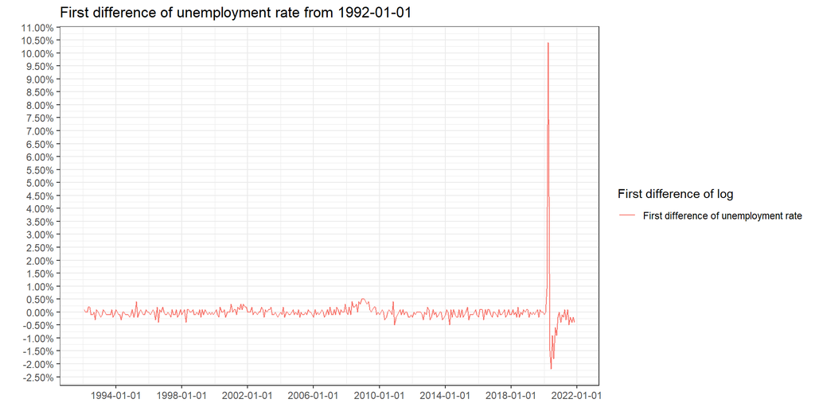

```r
ggplot(data=NULL,aes(x=final_ts_df$Date[-1]))+
  geom_line(aes(y=diff(final_ts_df$Unemployment_Rate),color="First difference of unemployment rate"))+ggtitle("First difference of unemployment rate from 1992-01-01")+theme_bw()+xlab(NULL)+scale_x_date(date_breaks="4 year")+
  scale_y_continuous(labels=scales::percent,breaks=scales::pretty_breaks(n=20))+labs(colour="First difference of log")+ylab("")
```

## Checking for stationarity and persistence of first difference:

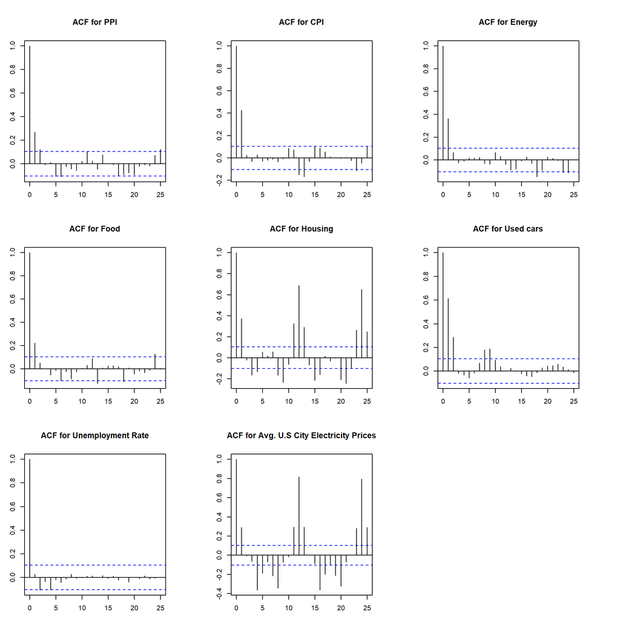

```r
par(mar = c(3,3,5,5))
par(mfrow=c(3,3))
acf(diff(log(final_ts_df$PPI)),main="ACF for PPI")
acf(diff(log(final_ts_df$CPI)),main="ACF for CPI")
acf(diff(log(final_ts_df$Energy)),main="ACF for Energy")
acf(diff(log(final_ts_df$Food)),main="ACF for Food")
acf(diff(log(final_ts_df$Housing_prices)),main="ACF for Housing")
acf(diff(log(final_ts_df$Used_cars)),main="ACF for Used cars")
acf(diff(final_ts_df$Unemployment_Rate),main="ACF for Unemployment Rate")
acf(diff(log(final_ts_df$AvgElectricityPrices)),main="ACF for Avg. U.S City Electricity Prices")
```

## Lag importance examination:

We want to run a regression of PPI and CPI against our response variables, but we also want to know if we should include any lags of our variables in the regressors as well. To do so, we choose to: 1. Run a regression of our variables with the lags with statistically significant autocorrelation from the ACF against CPI and PPI.. 2. Use a model F-test to determine if a model without lags could fit as well as a model with lags.

Food and Energy

```r
final_ts_df['log_Energy']=log(final_ts_df$Energy)
final_ts_df['diff_log_Energy']=difference(final_ts_df$log_Energy)
final_ts_df['lag_diff_log_Energy']=lag(final_ts_df$diff_log_Energy)
final_ts_df['log_Food']=log(final_ts_df$Food)
final_ts_df['diff_log_Food']=difference(final_ts_df$log_Food)
final_ts_df['lag_diff_log_Food']=lag(final_ts_df$diff_log_Food)
final_ts_df['log_CPI']=log(final_ts_df$CPI)
final_ts_df['diff_log_CPI']=difference(final_ts_df$log_CPI)
final_ts_df['log_PPI']=log(final_ts_df$PPI)
final_ts_df['diff_log_PPI']=difference(final_ts_df$log_PPI)
```

Housing and Used Cars

```r
final_ts_df['log_Housing'] = log(final_ts_df$Housing_prices)
final_ts_df['diff_log_Housing'] = difference(final_ts_df$log_Housing)
final_ts_df['lag_12_diff_log_Housing'] = lag(final_ts_df$diff_log_Housing, k = 12)
final_ts_df['log_Used_Cars'] = log(final_ts_df$Used_cars)
final_ts_df['diff_log_Used_Cars'] = difference(final_ts_df$log_Used_Cars)
final_ts_df['lag_diff_log_Used_Cars'] = lag(final_ts_df$diff_log_Used_Cars)
```

Electricity and Unemployment

```r
final_ts_df['diff_Unemployment']=difference(final_ts_df$Unemployment_Rate)
final_ts_df['lag_diff_Unemployment'] = lag(final_ts_df['diff_Unemployment'])
final_ts_df['log_AvgElectricityPrices']=log(final_ts_df$AvgElectricityPrices)
final_ts_df['diff_log_AvgElectricityPrices']=difference(final_ts_df$log_AvgElectricityPrices)
final_ts_df['lag_4_diff_log_AvgElectricityPrices'] = lag(final_ts_df$diff_log_AvgElectricityPrices, k = 4)
```

Model Building - CPI vs Energy and Food

```r
lag_CPI_Energy=lm(diff_log_CPI~diff_log_Energy+lag_diff_log_Energy,data=final_ts_df)
lag_CPI_Food=lm(diff_log_CPI~diff_log_Food+lag_diff_log_Food,data=final_ts_df)
modelsummary(list(lag_CPI_Energy,lag_CPI_Food),estimate="{estimate}{stars}")
```

|  | Model 1 | Model 2 |
| --- | --- | --- |
| (Intercept) | 0.002*** | 0.002*** |
|  | (0.000) | (0.000) |
| diff_log_Energy | 0.016*** |  |
|  | (0.001) |  |
| lag_diff_log_Energy | 0.016*** |  |
|  | (0.001) |  |
| diff_log_Food |  | 0.014** |
|  |  | (0.005) |
| lag_diff_log_Food |  | 0.024*** |
|  |  | (0.005) |
| Num.Obs. | 357 | 357 |
| R2 | 0.503 | 0.114 |
| R2 Adj. | 0.500 | 0.109 |
| AIC | -3465.2 | -3259.0 |
| BIC | -3449.7 | -3243.5 |
| Log.Lik. | 1736.620 | 1633.490 |
| F | 179.114 | 22.835 |